##### Analysis of the results of a survey about a sporting event which was held in Scotland

### Usual Residence of Respondents

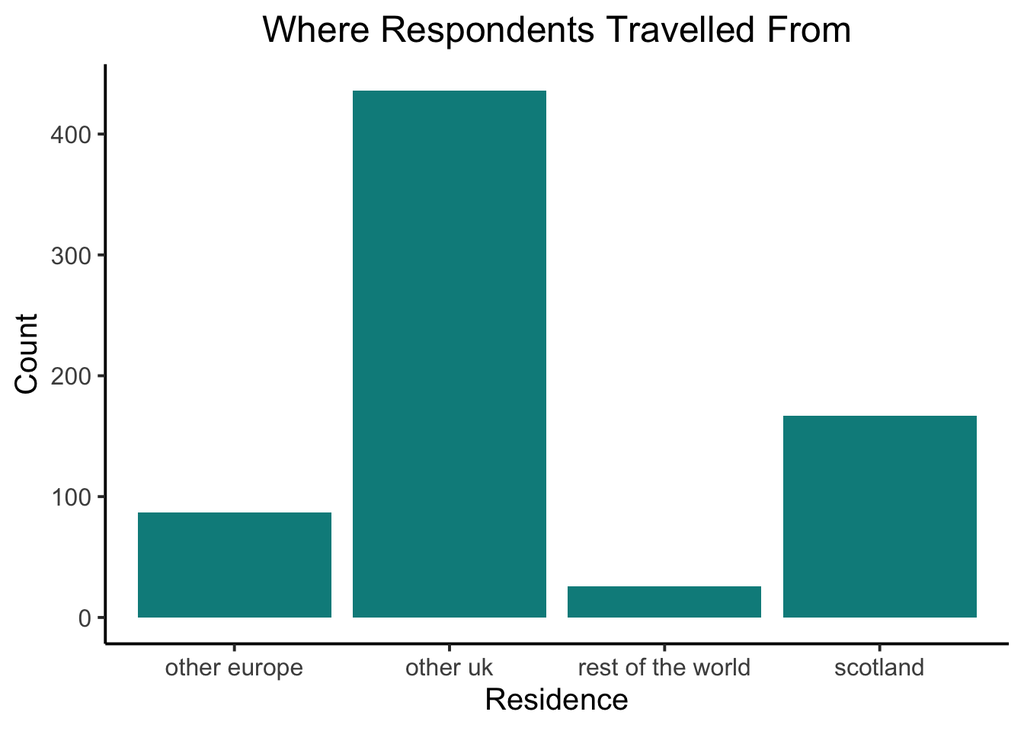

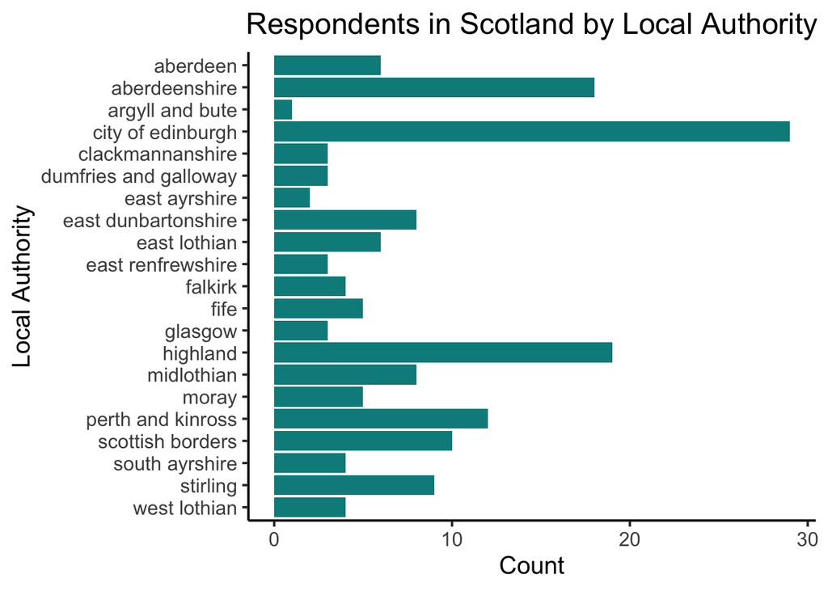

- Despite the event being held in Scotland, most of the respondents reported travelling from outwith Scotland, particularly the rest of the UK
- If the respondent travelled from Scotland, they were also asked to provide their local authority

### Transport

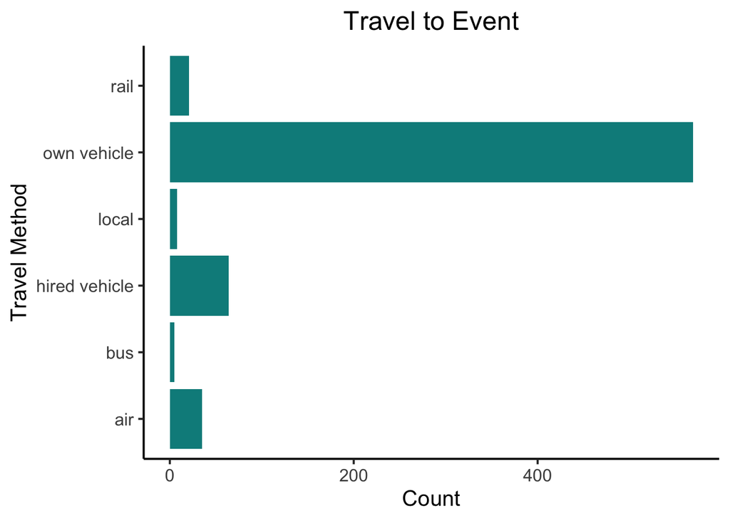

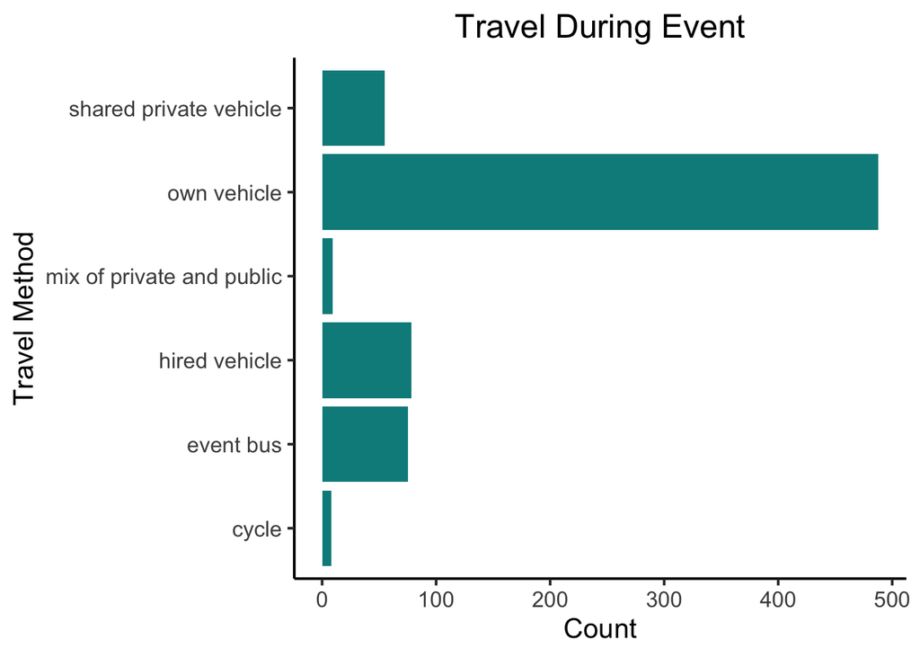

- The organisers are interested in reducing single car use and were interested in knowing about methods of travel both to and during the event
- The vast majority of respondents travelled to the event using their own vehicles
- The relatively remote location of the event may have prevented respondents from using public transport to travel there - this is perhaps something that could be considered when planning the next event
- Although the organisers organised a bus for the event, the take-up was not particularly high. It is possible that this could be attributed to the number of people who had already brought their own transport to the event

### Driving Distance

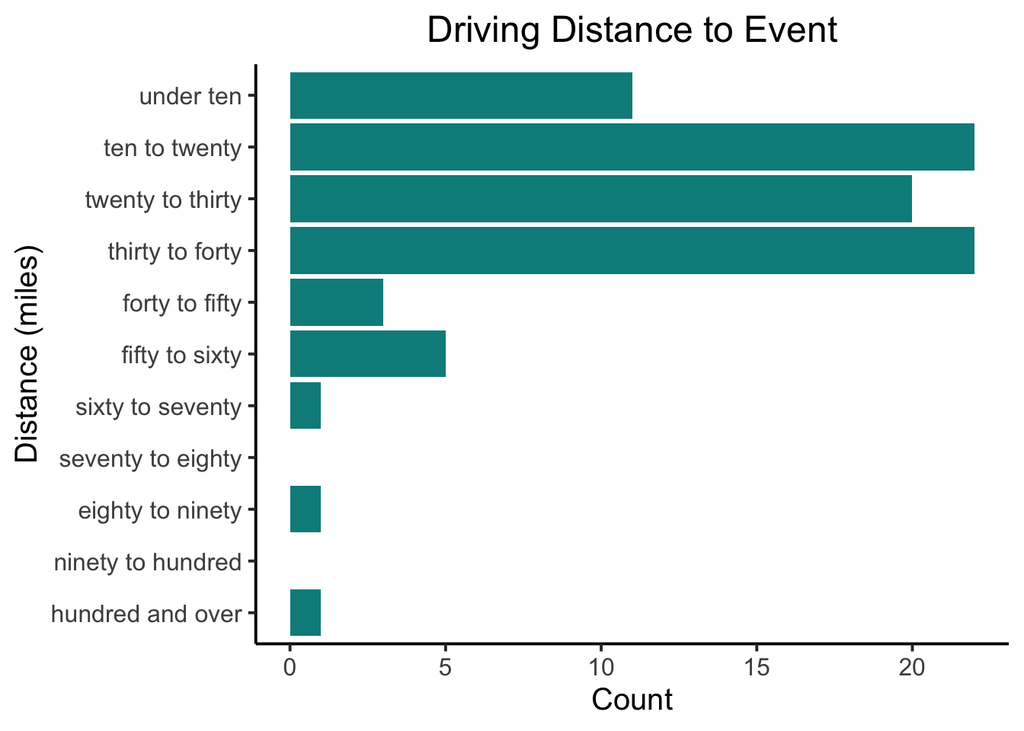

- Organisers wanted to know how far away from the event people are willing to stay
- The vast majority stayed no more than 40 miles away from the event
- The distances are Google’s estimated driving distances

### Accommodation

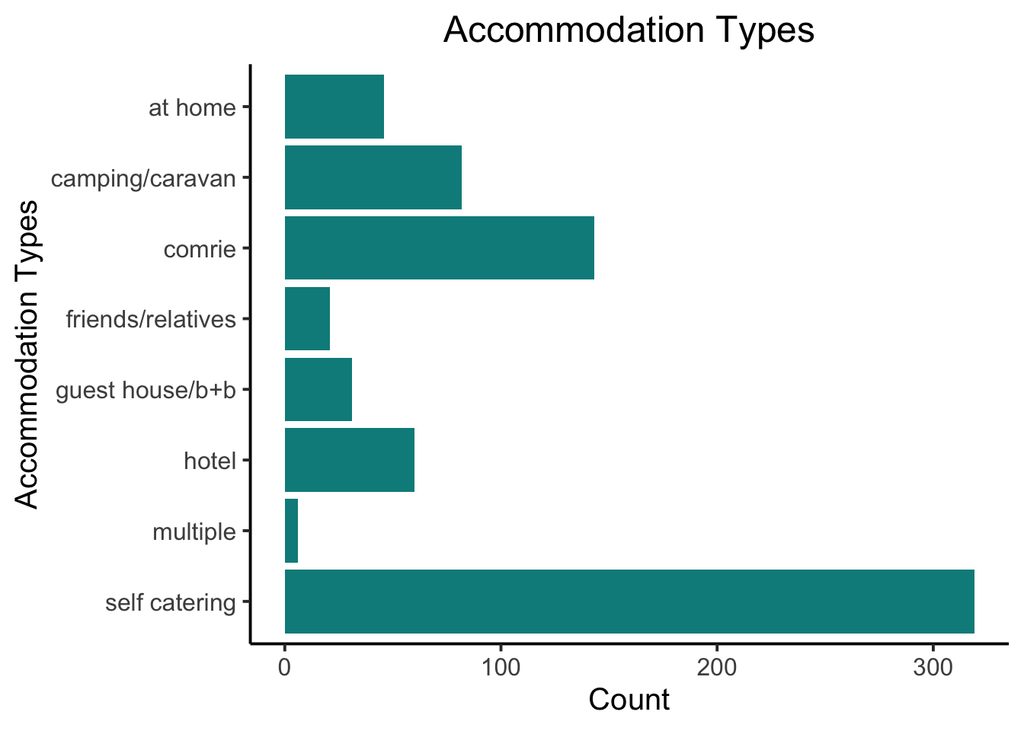

- Respondents stayed in 88 different cities, towns and villages in Scotland
- The most popular locations were: Comrie, Crieff and Perth
- 56% of respondents stayed in places with populations of under 500
- 49% of respondents stayed in self catering accommodation, spending an average of £882 on accommodation
- 18% stayed at the event campsite - Comrie Croft,spending an average of £194 on accommodation

### Digital Interaction with Event

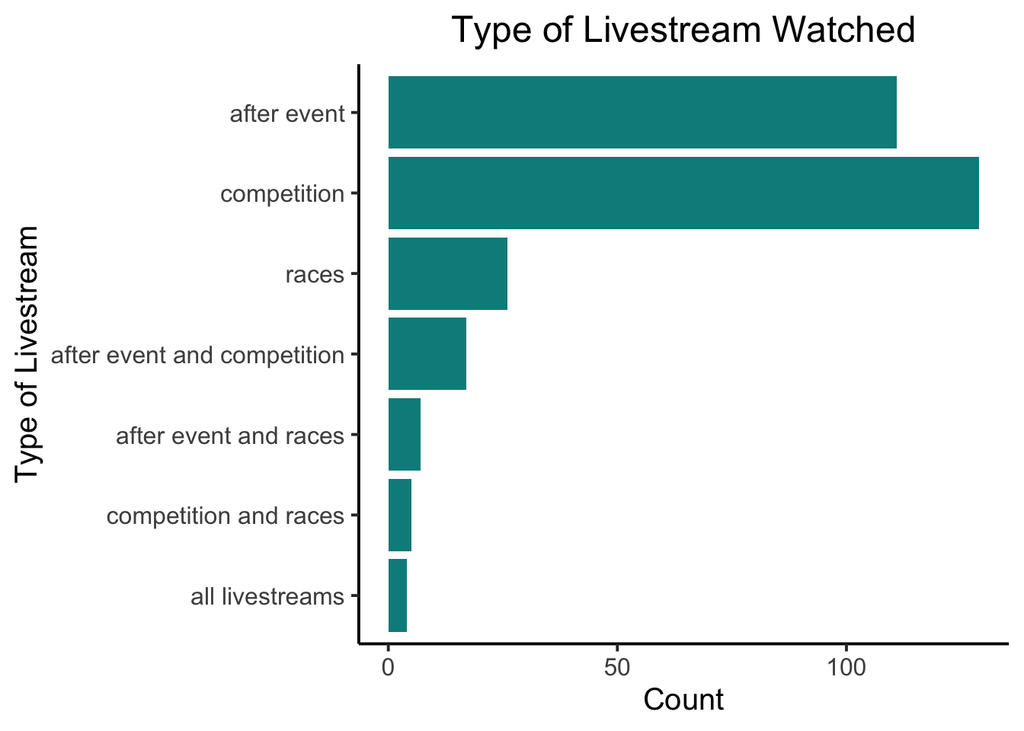

- The survey recorded different types of interaction with the livestream of the event
- Respondents were asked to state if they had watched the livestream after the event, during the competition or during the races
- Some respondents watched the livestream for two or more different categories
- Most people only watched one type of livestream
- In the free text comments, unreliable wifi was frequently mentioned and some respondents stated that this prevented them from watching the livestream during the event

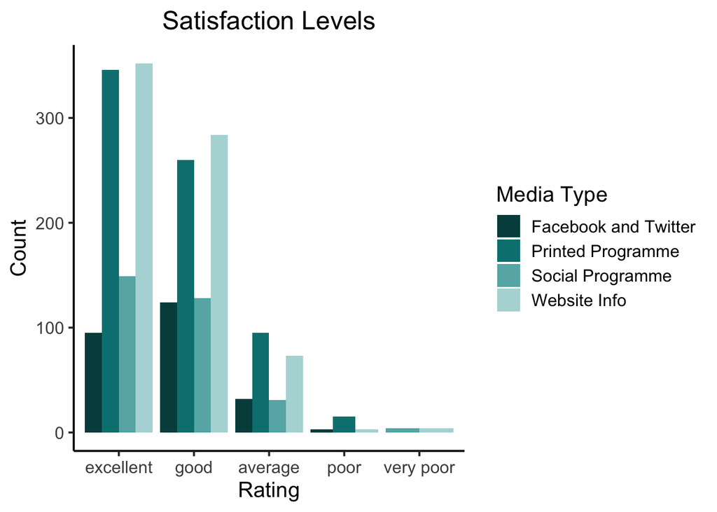

- Information about the events were disseminated to the attendees in a variety of different ways
- In the free text comments, many people mentioned that they missed the more detailed newsletter that was available at previous events

### Actionable Points

- Investigate increasing the availability of water during and after the event
- Review wifi availability
- Consider accessibility of public transport to social events

### Recommendations for Future Surveys

- Ask for more specific areas in other UK, if there are particularly popular areas, promoting shared transport in these areas could be promoted
- Supply more options for the respondents to select from drop down lists to allow for more efficient categorisation
- Ask about Twitter and Facebook separately to allow for analysis of popularity of different social media approaches
- Ask for ratings by day of event to enable the organisers to know which type of events are the most popular